# Final_tutorial

An Evaluation on Students' Earnings after obtaining a Bachelor's Degree:

By: Shifa Bhutta

Introduction:

The main purpose of this is to take you through the data sceince pipeline. As a college student myself, I have often wondered about student earnings and what effects them. Is it specific to a region and if the most expensive colleges are really worth it and lead to significantly higher paying jobs than colleges that do not cost as much. I will be using the US Department of [Education's](https://collegescorecard.ed.gov/data) database. This dataset is only applicable to students in America so that is the only country I will be looking at. Also, varying levels of degress (Bachelor's, Associate's,Masters,Doctorate) effects your earnings significantly. This tutorial will only focus on undergrads because that is the population I am most interested in. I used the csv file called: Most Recent Institution-Level Data that I found on their website.

This is important because it will help us predict what effects students' future earnings as well as gives an insight to how much schools matter and if there really is a signifcant difference in the careers between people who go to schools that cost more and people who do not. If not, then people should aim to save money in their education and not aim to go to expensive schools because after they have their degree, they will be making roughly the same amount of money, but if they went to an expensive school they will have more debt.

These are all of the libraries imported for the analysis

```python
#dataframe
import pandas as pd

#graphing
import matplotlib.pyplot as plt
import matplotlib.patches as mpatches
import seaborn as sns
import numpy as np

#models
import statsmodels.api as sm
import statsmodels.formula.api as smf
from sklearn.linear_model import LinearRegression
from sklearn.model_selection import train_test_split
from sklearn.metrics import mean_squared_error
```

creates a dataframe from the csv file.

We import: INSTNM - institute name

CITY - city where college is located

STABBR - state abbreviation

PREDDEG - predominant undergraduate degree awarded

ICLEVEL - level of institution

ADM_RATE - admission rate

TUITIONFEE_IN - in state tuition fee

TUITIONFEE_OUT - out of state tuition

GRAD_DEBT_MDN - is a measure of the usual debt  
accumualted by a student over the 4 year period

BBRR2_FED_UGCOMP_PAIDINFULL_SUPP - percent of student who paid their debt in full

MD_EARN_WNE_P10 - median earnings of students after they have graduated

ROOMBOARD_ON/OFF - cost of room/board for on/off campus

OTHER_EXPENSE_OFF/ON - other expenses for going to the school

```python
#name of file
file = 'Most-Recent-Cohorts-Institution.csv'

df = pd.read_csv(file, low_memory=False)

df.head()

#includes admission rate, city, state abbr,expenses, earnings, debt,etc.
features = ['INSTNM', 'CITY', 'STABBR', 'PREDDEG', 'ICLEVEL', 'ADM_RATE', 'UGDS',
            'TUITIONFEE_IN', 'TUITIONFEE_OUT','GRAD_DEBT_MDN',
            'BOOKSUPPLY', 'ROOMBOARD_ON', 'OTHEREXPENSE_ON',
            'ROOMBOARD_OFF', 'OTHEREXPENSE_OFF', 'MD_EARN_WNE_P10',
            'BBRR2_FED_UGCOMP_PAIDINFULL_SUPP']

#displays dataframe
pd.set_option('display.max_rows', 30)
df_features = df[features]
df_features
```

|  | INSTNM | CITY | STABBR | PREDDEG | ICLEVEL | ADM_RATE | UGDS | TUITIONFEE_IN | TUITIONFEE_OUT | GRAD_DEBT_MDN | BOOKSUPPLY | ROOMBOARD_ON | OTHEREXPENSE_ON | ROOMBOARD_OFF | OTHEREXPENSE_OFF | MD_EARN_WNE_P10 | BBRR2_FED_UGCOMP_PAIDINFULL_SUPP |
| --- | --- | --- | --- | --- | --- | --- | --- | --- | --- | --- | --- | --- | --- | --- | --- | --- | --- |
| 0 | Alabama A & M University | Normal | AL | 3 | 1 | 0.7160 | 5098.0 | 10024.0 | 18634.0 | 31000 | 1600.0 | 9520.0 | 3090.0 | 9520.0 | 3090.0 | 39059.0 | PrivacySuppressed |
| 1 | University of Alabama at Birmingham | Birmingham | AL | 3 | 1 | 0.8854 | 13284.0 | 8568.0 | 20400.0 | 22300 | 1200.0 | 12307.0 | 5555.0 | 12307.0 | 5555.0 | 50907.0 | 0.06289779108948 |
| 2 | Amridge University | Montgomery | AL | 3 | 1 | NaN | 251.0 | NaN | NaN | 32189 | NaN | NaN | NaN | NaN | NaN | 37730.0 | PrivacySuppressed |
| 3 | University of Alabama in Huntsville | Huntsville | AL | 3 | 1 | 0.7367 | 7358.0 | 11488.0 | 23884.0 | 20705 | 2300.0 | 10764.0 | 4156.0 | 10764.0 | 4156.0 | 56901.0 | 0.09598603839442 |
| 4 | Alabama State University | Montgomery | AL | 3 | 1 | 0.9799 | 3495.0 | 11068.0 | 19396.0 | 31000 | 1600.0 | 6050.0 | 3392.0 | 7320.0 | 5130.0 | 34018.0 | PrivacySuppressed |
| ... | ... | ... | ... | ... | ... | ... | ... | ... | ... | ... | ... | ... | ... | ... | ... | ... | ... |
| 6538 | Pennsylvania State University-Penn State York | York | PA | 0 | 1 | NaN | NaN | 14838.0 | 24110.0 | 25000 | NaN | NaN | NaN | NaN | NaN | 61185.0 | 0.12476495962836 |
| 6539 | Pennsylvania State University-Penn State Great... | Malvern | PA | 0 | 1 | NaN | NaN | NaN | NaN | 25000 | NaN | NaN | NaN | NaN | NaN | 61185.0 | 0.12476495962836 |
| 6540 | Pennsylvania State University-Penn State Harri... | Middletown | PA | 0 | 1 | NaN | NaN | 15586.0 | 25600.0 | 25000 | NaN | NaN | NaN | NaN | NaN | 61185.0 | 0.12476495962836 |
| 6541 | Pennsylvania State University-Penn State Brand... | Media | PA | 0 | 1 | NaN | NaN | 14838.0 | 24110.0 | 25000 | NaN | NaN | NaN | NaN | NaN | 61185.0 | 0.12476495962836 |
| 6542 | Burlington County Institute of Technology - Ad... | Medford | NJ | 0 | 3 | NaN | NaN | NaN | NaN | NaN | NaN | NaN | NaN | NaN | NaN | NaN | NaN |

6543 rows × 17 columns

Now that we have a dataframe with the features we want, I have to clean the data. I calculated the mean of offcampus expenses for cities or states depending on if there was enough city data and put them in for the missing values. For on campus, I replaced them with 0s because many of those schools did not offer dorms or other amenities that students would need to pay for.

I just dropped all universities with null values in the admission rate because replacing them with the mean or anything else might skew the data. Also any missing values in "GRAD_DEBT_MDN", I also dropped because calculating the mean might skew the data because even schools in the same state have different levels of debt. I did not drop based off of tuition values because those schools are military schools and are paid for by the military, so I just replaced them with 0s. I also filled in 0s for values that were missing in the "paid in full" column because those values are so low anyway that the mean would not be significantly greater than 0 and there were too many missing values for me to consider dropping rows.

Because of how important median earning for each school is to our conclusion, I dropped every row where that value is missing.

```python
#find all undergrad data and store it in a dataframe
df_undergrad = df_features.loc[(df_features['ICLEVEL'] == 1) & (df_features['PREDDEG'] == 3)]

#replace "PrivacySuppressed with Nan"
df_undergrad.replace('PrivacySuppressed', np.nan)

#drop rows where any of these values are null
df_undergrad = df_undergrad.dropna(subset=['ADM_RATE'])
df_undergrad = df_undergrad.dropna(subset=['MD_EARN_WNE_P10'])
df_undergrad = df_undergrad.dropna(subset=['GRAD_DEBT_MDN'])

#stores all values where they are both null
df_offcampus_na =  df_undergrad[df_undergrad['ROOMBOARD_OFF'].isnull() & df_undergrad['OTHEREXPENSE_OFF'].isnull()]
#finds mean based off of city data
for row in df_offcampus_na['CITY']:
    roomboard = df_undergrad[df_undergrad['CITY'] == row]['ROOMBOARD_OFF'].mean()
    otherexpense = df_undergrad[df_undergrad['CITY'] == row]['OTHEREXPENSE_OFF'].mean()

    df_undergrad.loc[(df_undergrad['CITY'] == row) & (df_undergrad['ROOMBOARD_OFF'].isnull()) , 'ROOMBOARD_OFF'] = round(roomboard, 2)
    df_undergrad.loc[(df_undergrad['CITY'] == row) & (df_undergrad['OTHEREXPENSE_OFF'].isnull()) , 'OTHEREXPENSE_OFF'] = round(otherexpense, 2)
#if city data is not available, then bases it off state mean
for row in df_offcampus_na['STABBR']:
    roomboard = df_undergrad[df_undergrad['STABBR'] == row]['ROOMBOARD_OFF'].mean()
    otherexpense = df_undergrad[df_undergrad['STABBR'] == row]['OTHEREXPENSE_OFF'].mean()

    df_undergrad.loc[(df_undergrad['STABBR'] == row) & (df_undergrad['ROOMBOARD_OFF'].isnull()) , 'ROOMBOARD_OFF'] = round(roomboard, 2)
    df_undergrad.loc[(df_undergrad['STABBR'] == row) & (df_undergrad['OTHEREXPENSE_OFF'].isnull()) , 'OTHEREXPENSE_OFF'] = round(otherexpense, 2)


#fills in values with 0s
df_undergrad['ROOMBOARD_ON'] = df_undergrad['ROOMBOARD_ON'].fillna(0)
df_undergrad['OTHEREXPENSE_ON'] = df_undergrad['OTHEREXPENSE_ON'].fillna(0)
df_undergrad['BOOKSUPPLY'] = df_undergrad['BOOKSUPPLY'].fillna(0)
df_undergrad['TUITIONFEE_IN'] = df_undergrad['TUITIONFEE_IN'].fillna(0)
df_undergrad['TUITIONFEE_OUT'] = df_undergrad['TUITIONFEE_OUT'].fillna(0)
df_undergrad['BBRR2_FED_UGCOMP_PAIDINFULL_SUPP'] = df_undergrad['BBRR2_FED_UGCOMP_PAIDINFULL_SUPP'].fillna(0)

df_undergrad.isnull().sum()
```

```
INSTNM                              0
CITY                                0
STABBR                              0
PREDDEG                             0
ICLEVEL                             0
ADM_RATE                            0
UGDS                                0
TUITIONFEE_IN                       0
TUITIONFEE_OUT                      0
GRAD_DEBT_MDN                       0
BOOKSUPPLY                          0
ROOMBOARD_ON                        0
OTHEREXPENSE_ON                     0
ROOMBOARD_OFF                       0
OTHEREXPENSE_OFF                    0
MD_EARN_WNE_P10                     0
BBRR2_FED_UGCOMP_PAIDINFULL_SUPP    0
dtype: int64
```

Exploratory Analasysis and Data Visualization

The whole point of this section is to do a further analysis to get a better understanding of our data. This is for a better understanding of the relationships between our data which will later be used to make a model.

Fisrt, a scatterplot is made between student debt and student earnings to see the relationship between them. It appears as though most students earn between 40-60k and are in debt 20-25k. The GRAD_DEBT_MD is a measure of the usual [debt](https://collegescorecard.ed.gov/data/glossary/) accumualted by a student over the 4 year period. We measure that against the median earnings of students. Students included in this statistic are not currently enrolled in school.

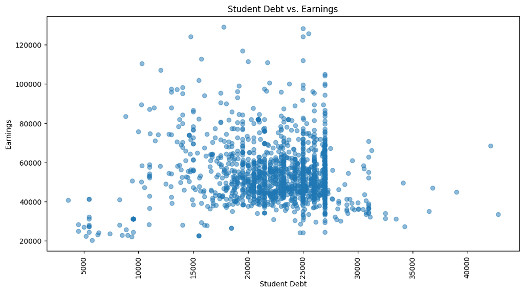

```python
#converts GRAD_DEBT_MDN from object to integer
df_undergrad['GRAD_DEBT_MDN'] = pd.to_numeric(df_undergrad['GRAD_DEBT_MDN'], errors='coerce')

#graphs debt vs. earnings
plt.figure(figsize=(12, 6))
x = df_undergrad['GRAD_DEBT_MDN']
y = df_undergrad['MD_EARN_WNE_P10']
plt.scatter(x, y, alpha=0.5)
plt.plot()
plt.xlabel('Student Debt')
plt.ylabel('Earnings')
plt.title('Student Debt vs. Earnings')


# Set tick positions in ascending order at an interval
plt.xticks(rotation='vertical')
plt.show()
data_type = df_undergrad['GRAD_DEBT_MDN'].dtypes
```

A bar graph to show the same relationship but in a different format to have an understanding of the relationship between earnings and debt.

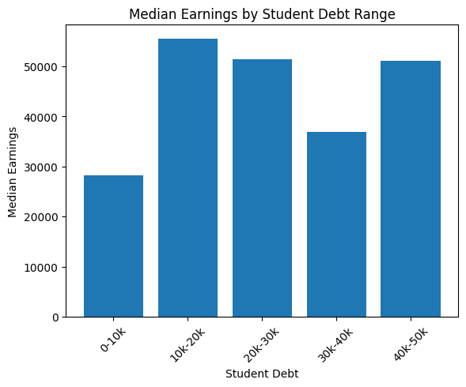

```python
bins = [0, 10000, 20000, 30000, 40000, 50000, 100000]
labels = ['0-10k', '10k-20k', '20k-30k', '30k-40k', '40k-50k', '50k+']
df_undergrad['debt_bin'] = pd.cut(df_undergrad['GRAD_DEBT_MDN'], bins=bins, labels=labels)

# Calculate median earnings for each debt bin
aggregated_data = df_undergrad.groupby('debt_bin')['MD_EARN_WNE_P10'].median()

plt.bar(aggregated_data.index, aggregated_data)
plt.xlabel('Student Debt')
plt.ylabel('Median Earnings')
plt.title('Median Earnings by Student Debt Range')
plt.xticks(rotation=45)
plt.show()
```

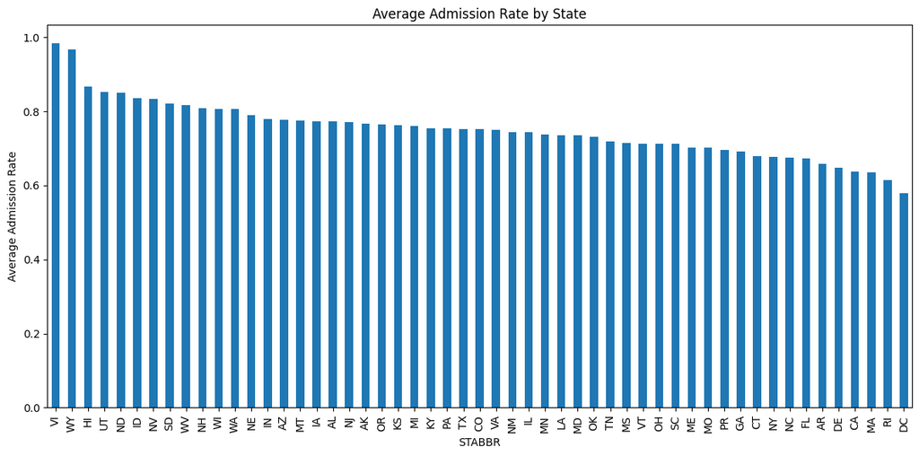

```python
admission_by_state = df_undergrad.groupby('STABBR')['ADM_RATE'].mean()

# Sort the admission rates in descending order
admission_by_state = admission_by_state.sort_values(ascending=False)

# Create a bar plot for admission rates by state
plt.figure(figsize=(12, 6))
admission_by_state.plot(kind='bar')
plt.xlabel('STABBR')
plt.ylabel('Average Admission Rate')
plt.title('Average Admission Rate by State')
plt.xticks(rotation='vertical')
plt.tight_layout()

plt.show()
```

Now, that we know that relationship, we can further explore how admission rate correlates to debt and earnings. Again, the results are similar to the plot above because most states have similar results. There is a cluster around $22500.

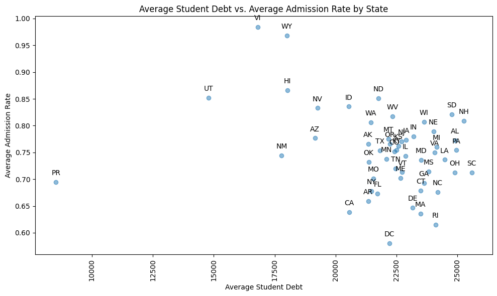

```python
#groups by state and finds mean of debt and admission rate
state_stats = df_undergrad.groupby('STABBR')[['GRAD_DEBT_MDN', 'ADM_RATE']].mean()

#creates a scatter plot for average student debt vs average admission rate
plt.figure(figsize=(10, 6))
plt.scatter(state_stats['GRAD_DEBT_MDN'], state_stats['ADM_RATE'], alpha=0.5)

plt.xlabel('Average Student Debt')
plt.ylabel('Average Admission Rate')
plt.title('Average Student Debt vs. Average Admission Rate by State')
plt.xticks(rotation='vertical')
plt.tight_layout()

#labels and displays
for state, row in state_stats.iterrows():
    plt.annotate(state, (row['GRAD_DEBT_MDN'], row['ADM_RATE']), textcoords="offset points", xytext=(0,10), ha='center')

plt.show()
```

For average student earnings vs. admission rate, there appears to be a stronger correlation. The data almost makes a bell-curve shape which is different from the other 2 graphs because they did not have any shape. That being said, there is still clustering, and the correlation does not appear to be very strong, but it does appear to be exist.

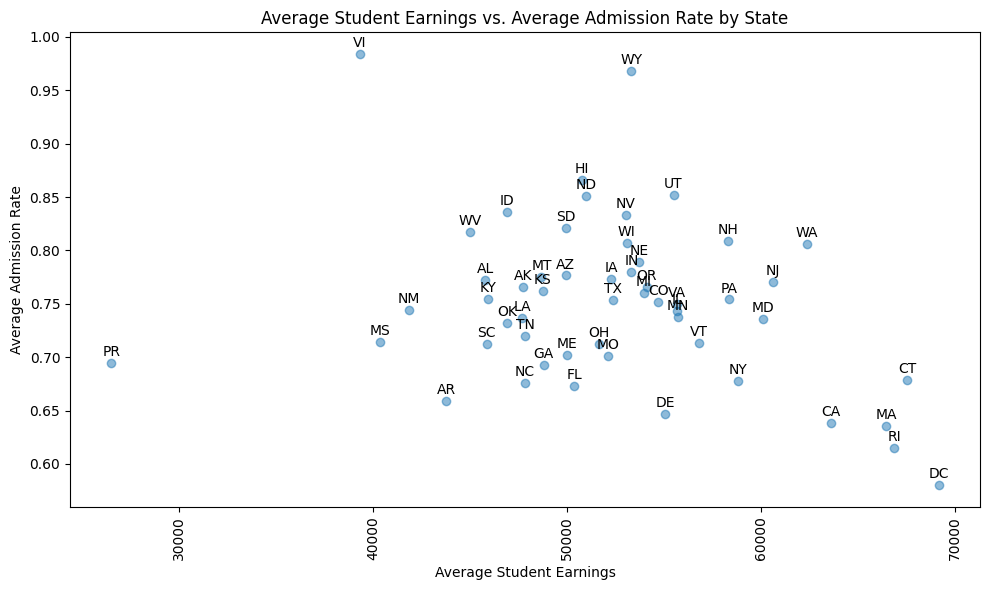

```python
state_stats = df_undergrad.groupby('STABBR')[['MD_EARN_WNE_P10', 'ADM_RATE']].mean()

# Create a scatter plot for average student debt vs average admission rate
plt.figure(figsize=(10, 6))
plt.scatter(state_stats['MD_EARN_WNE_P10'], state_stats['ADM_RATE'], alpha=0.5)

plt.xlabel('Average Student Earnings')
plt.ylabel('Average Admission Rate')
plt.title('Average Student Earnings vs. Average Admission Rate by State')
plt.xticks(rotation='vertical')
plt.tight_layout()

for state, row in state_stats.iterrows():
    plt.annotate(state, (row['MD_EARN_WNE_P10'], row['ADM_RATE']), textcoords="offset points", xytext=(0,5), ha='center',fontsize=10)

plt.show()
```

I created a new column called regions to see if by grouping the sates, we would see any patterns. I graphed it with instate tuition costs and out of state tuition costs. They were roughly the same. The North was the most expensive and the south was the least expensive.

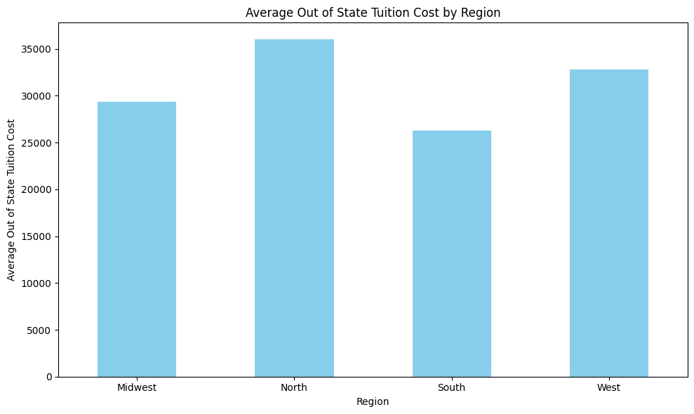

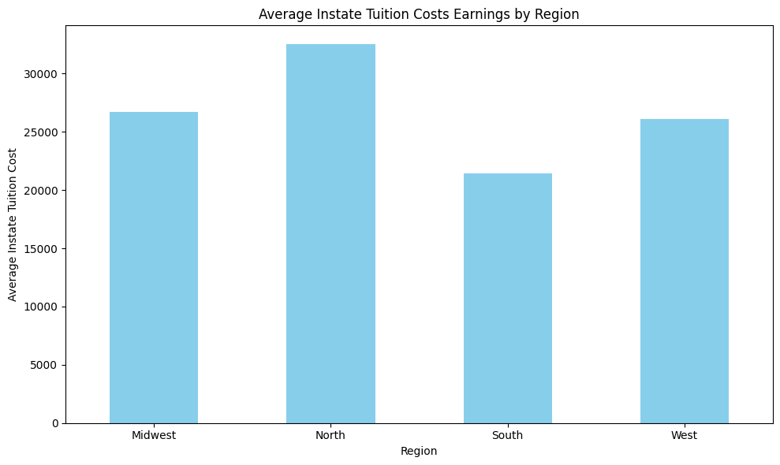

```python
#Defines a dictionary to map states to regions
state_to_region = {
    'AL': 'South', 'AK': 'North', 'AZ': 'West', 'AR': 'South', 'CA': 'West',
    'CO': 'West', 'CT': 'North', 'DE': 'North', 'FL': 'South', 'GA': 'South',
    'HI': 'North', 'ID': 'West', 'IL': 'Midwest', 'IN': 'Midwest', 'IA': 'Midwest',
    'KS': 'Midwest', 'KY': 'South', 'LA': 'South', 'ME': 'North', 'MD': 'North',
    'MA': 'North', 'MI': 'Midwest', 'MN': 'Midwest', 'MS': 'South', 'MO': 'Midwest',
    'MT': 'West', 'NE': 'Midwest', 'NV': 'West', 'NH': 'North', 'NJ': 'North',
    'NM': 'West', 'NY': 'North', 'NC': 'South', 'ND': 'Midwest', 'OH': 'Midwest',
    'OK': 'South', 'OR': 'West', 'PA': 'North', 'RI': 'North', 'SC': 'South',
    'SD': 'Midwest', 'TN': 'South', 'TX': 'South', 'UT': 'West', 'VT': 'North',
    'VA': 'South', 'WA': 'West', 'WV': 'South', 'WI': 'Midwest', 'WY': 'West'
}

df_undergrad['regions'] = df_undergrad['STABBR'].map(state_to_region)

region_debt_stats = df_undergrad.groupby('regions')['TUITIONFEE_OUT'].mean()

#creates a bar plot for average student debt by region
plt.figure(figsize=(10, 6))
region_debt_stats.plot(kind='bar', color='skyblue')
plt.xlabel('Region')
plt.ylabel('Average Out of State Tuition Cost')
plt.title('Average Out of State Tuition Cost by Region')
plt.xticks(rotation='horizontal')
plt.tight_layout()

plt.show()

region_debt_stats = df_undergrad.groupby('regions')['TUITIONFEE_IN'].mean()

#create a bar plot for average student debt by region
plt.figure(figsize=(10, 6))
region_debt_stats.plot(kind='bar', color='skyblue')
plt.xlabel('Region')
plt.ylabel('Average Instate Tuition Cost')
plt.title('Average Instate Tuition Costs Earnings by Region')
plt.xticks(rotation='horizontal')
plt.tight_layout()

plt.show()
```

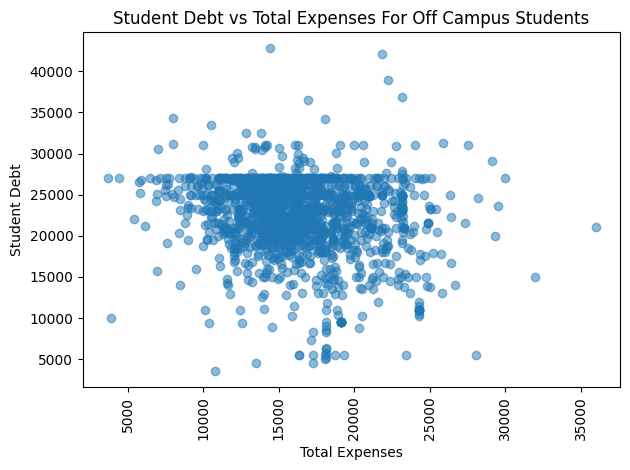

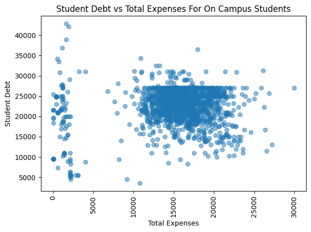

```python
#calculates total expenses for on and off students
df_undergrad['total_expenses_off'] = df_undergrad['ROOMBOARD_OFF'] + df_undergrad['OTHEREXPENSE_OFF'] + df_undergrad['BOOKSUPPLY']
df_undergrad['total_expenses_on'] = df_undergrad['ROOMBOARD_ON'] + df_undergrad['OTHEREXPENSE_ON'] + df_undergrad['BOOKSUPPLY']

#graphs and displays for off campus
plt.scatter(df_undergrad['total_expenses_off'], df_undergrad['GRAD_DEBT_MDN'], alpha=0.5)
plt.ylabel('Student Debt')
plt.xlabel('Total Expenses')
plt.title('Student Debt vs Total Expenses For Off Campus Students')
plt.xticks(rotation='vertical')
plt.tight_layout()

plt.show()

#graphs and displays for on campus
plt.scatter(df_undergrad['total_expenses_on'], df_undergrad['GRAD_DEBT_MDN'], alpha=0.5)
plt.ylabel('Student Debt')
plt.xlabel('Total Expenses')
plt.title('Student Debt vs Total Expenses For On Campus Students')
plt.xticks(rotation='vertical')
plt.tight_layout()

plt.show()
```

I grouped the data by state and calculated the mean earnings and tuition fees. Then, I plotted my data. Both of the plots show a linear relationhip. The higher the cost of the institution, the more the student earns.

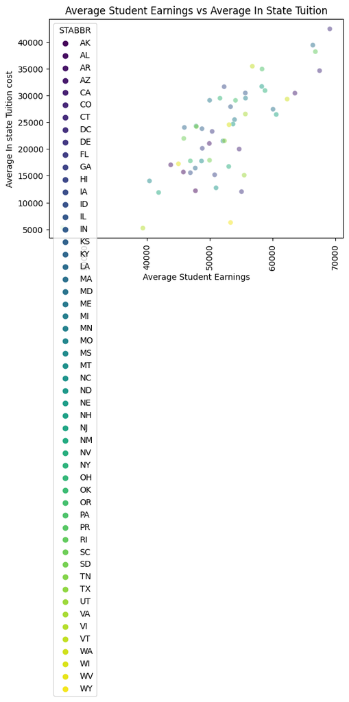

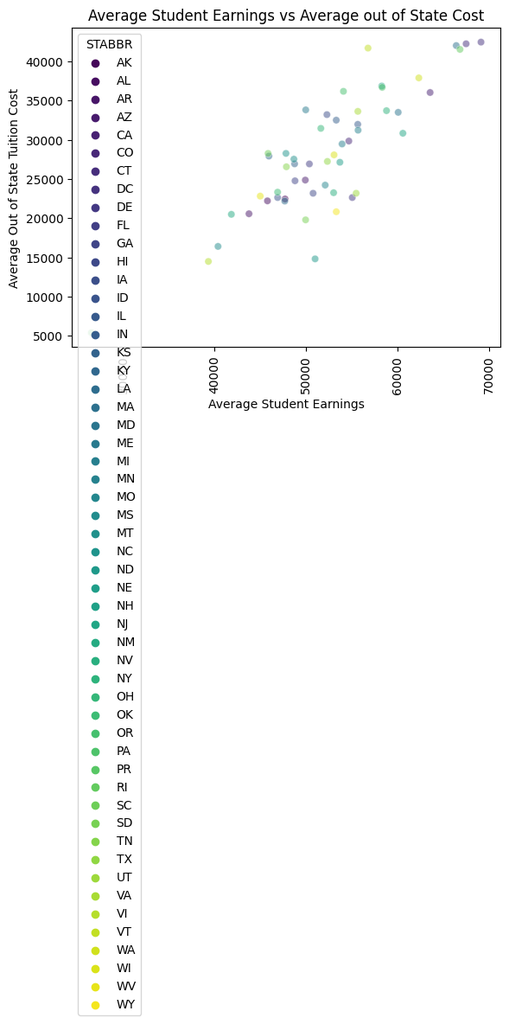

```python
#grouped by stae and calculates mean of earnings and tuition fees
state_stats = df_undergrad.groupby('STABBR')[['MD_EARN_WNE_P10', 'TUITIONFEE_IN']].mean()
x = df_undergrad.groupby('STABBR')['MD_EARN_WNE_P10'].mean()
y = df_undergrad.groupby('STABBR')['TUITIONFEE_IN'].mean()

#plots data for in state tuition fees
sns.scatterplot(data=state_stats, x='MD_EARN_WNE_P10', y='TUITIONFEE_IN', hue=state_stats.index, palette='viridis', alpha=0.5)
plt.xlabel('Average Student Earnings')
plt.ylabel('Average In state Tuition cost')
plt.title('Average Student Earnings vs Average In State Tuition')
plt.xticks(rotation='vertical')


plt.show()

#plots data for out of state tuition fees
state_stats = df_undergrad.groupby('STABBR')[['MD_EARN_WNE_P10', 'TUITIONFEE_OUT']].mean()
y = df_undergrad.groupby('STABBR')['TUITIONFEE_OUT'].mean()
sns.scatterplot(data=state_stats, x='MD_EARN_WNE_P10', y='TUITIONFEE_OUT', hue=state_stats.index, palette='viridis', alpha=0.5)
plt.xlabel('Average Student Earnings')
plt.ylabel('Average Out of State Tuition Cost')
plt.title('Average Student Earnings vs Average out of State Cost')
plt.xticks(rotation='vertical')



plt.show()
```

I graphed the proportion of students who have paid back their loan by region and found that the graph looks identical to the one of tuition costs grouped by region. It seems as though people who are able to go to expensive schools can also afford them.

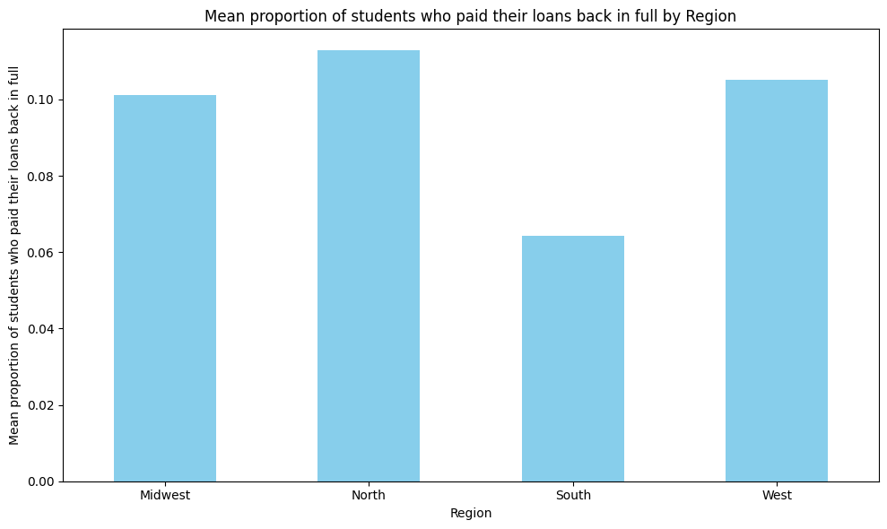

```python
#coverts column from object to integer
df_undergrad['BBRR2_FED_UGCOMP_PAIDINFULL_SUPP'] = pd.to_numeric(df_undergrad['BBRR2_FED_UGCOMP_PAIDINFULL_SUPP'], errors='coerce')

#groups by region and finds the mean
region_paid_in_full = df_undergrad.groupby('regions')['BBRR2_FED_UGCOMP_PAIDINFULL_SUPP'].mean()

#create a bar graph for 'BBRR2_FED_UGCOMP_PAIDINFULL_SUPP' by region
plt.figure(figsize=(10, 6))
region_paid_in_full.plot(kind='bar', color='skyblue')
plt.xlabel('Region')
plt.ylabel('Mean proportion of students who paid their loans back in full')
plt.title('Mean proportion of students who paid their loans back in full by Region')
plt.xticks(rotation='horizontal')
plt.tight_layout()

plt.show()
```

This graph shows the relationship between student debt and students who paid their debt back. It does not show what I expected which was the samller the debt, the more likely to be paid in full. Most of the debt that was paid was between 22500 and 25000.

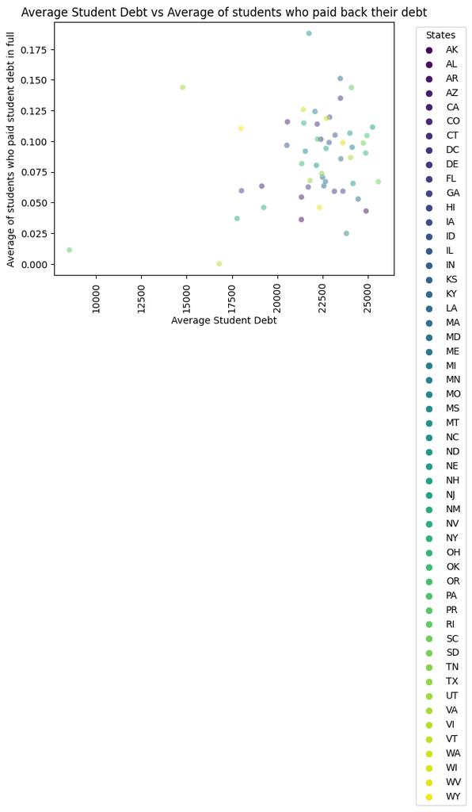

```python
#resets data to 0s and drops rows if deemed necessary
df_undergrad['BBRR2_FED_UGCOMP_PAIDINFULL_SUPP'] = df_undergrad['BBRR2_FED_UGCOMP_PAIDINFULL_SUPP'].fillna(0)
df_undergrad = df_undergrad.dropna(subset=['GRAD_DEBT_MDN'])

#calculates mean of debt and students who paid debt back
state_stats = df_undergrad.groupby('STABBR')[['GRAD_DEBT_MDN', 'BBRR2_FED_UGCOMP_PAIDINFULL_SUPP']].mean()

#plots data
sns.scatterplot(data=state_stats, x='GRAD_DEBT_MDN', y='BBRR2_FED_UGCOMP_PAIDINFULL_SUPP', hue=state_stats.index, palette='viridis', alpha=0.5)
plt.xlabel('Average Student Debt')
plt.ylabel('Average of students who paid student debt in full')
plt.title('Average Student Debt vs Average of students who paid back their debt')
plt.xticks(rotation='vertical')


plt.legend(title='States', bbox_to_anchor=(1.05, 1), loc='upper left')

plt.show()
```

Model: Analysis, Hypothesis Testing, Machine Learning

Machine learning involves the use of algorithms to develop models that can learn from data and make predictions or decisions without being explicitly programmed. These models aim to find patterns, relationships, and trends in data and generalize them to new, unseen data.

I made a regression line to get a better understanding between earning and debt, and the realtionship is weak because the majority of the data is nowhere near the line.

```
                            OLS Regression Results
==============================================================================
Dep. Variable:        MD_EARN_WNE_P10   R-squared:                       0.002
Model:                            OLS   Adj. R-squared:                  0.002
Method:                 Least Squares   F-statistic:                     3.285
Date:                Mon, 21 Aug 2023   Prob (F-statistic):             0.0701
Time:                        01:59:50   Log-Likelihood:                -16467.
No. Observations:                1494   AIC:                         3.294e+04
Df Residuals:                    1492   BIC:                         3.295e+04
Df Model:                           1
Covariance Type:            nonrobust
=================================================================================
                    coef    std err          t      P>|t|      [0.025      0.975]
---------------------------------------------------------------------------------
const          5.755e+04   1901.430     30.265      0.000    5.38e+04    6.13e+04
GRAD_DEBT_MDN    -0.1496      0.083     -1.812      0.070      -0.312       0.012
==============================================================================
Omnibus:                      333.067   Durbin-Watson:                   1.540
Prob(Omnibus):                  0.000   Jarque-Bera (JB):              850.409
Skew:                           1.180   Prob(JB):                    2.17e-185
Kurtosis:                       5.844   Cond. No.                     1.14e+05
==============================================================================

Notes:
[1] Standard Errors assume that the covariance matrix of the errors is correctly specified.
[2] The condition number is large, 1.14e+05. This might indicate that there are
strong multicollinearity or other numerical problems.
```

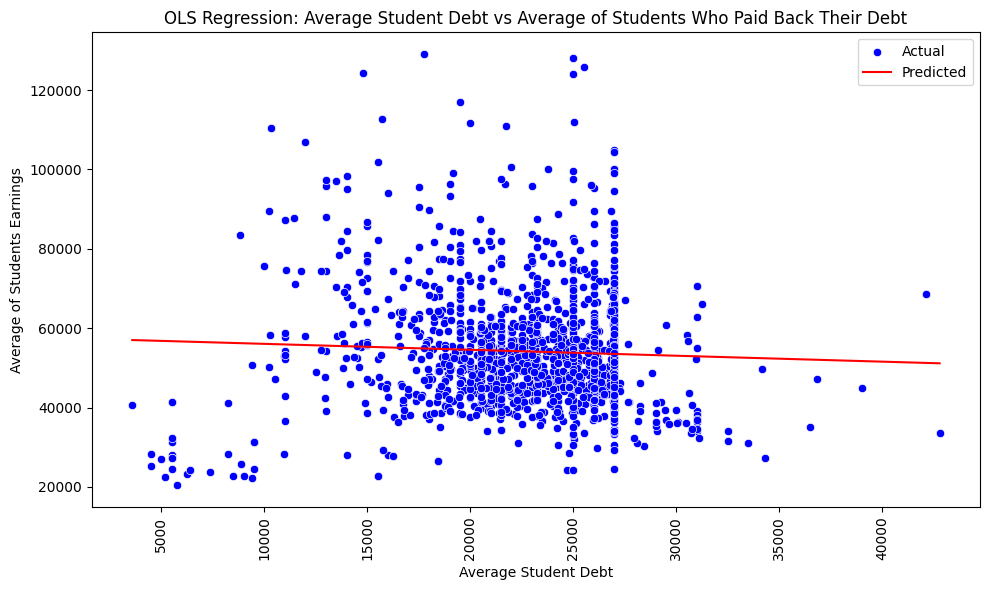

```python
X = df_undergrad[['GRAD_DEBT_MDN']]
y = df_undergrad['MD_EARN_WNE_P10']
df_undergrad.isnull().sum()

#adds a constant term to the features (for the intercept)
X = sm.add_constant(X)

#creates and fit the OLS model
model = sm.OLS(y, X).fit()

#print the model summary
print(model.summary())

#creates a scatter plot with the OLS regression line
plt.figure(figsize=(10, 6))
sns.scatterplot(x=X['GRAD_DEBT_MDN'], y=y, color='blue', label='Actual')
sns.lineplot(x=X['GRAD_DEBT_MDN'], y=model.predict(X), color='red', label='Predicted')
plt.xlabel('Average Student Debt')
plt.ylabel('Average of Students Earnings')
plt.title('OLS Regression: Average Student Debt vs Average of Students Who Paid Back Their Debt')
plt.legend()
plt.xticks(rotation='vertical')
plt.tight_layout()

plt.show()
```

```
                                   OLS Regression Results
============================================================================================
Dep. Variable:     BBRR2_FED_UGCOMP_PAIDINFULL_SUPP   R-squared:                       0.461
Model:                                          OLS   Adj. R-squared:                  0.460
Method:                               Least Squares   F-statistic:                     1274.
Date:                              Mon, 21 Aug 2023   Prob (F-statistic):          3.13e-202
Time:                                      01:59:57   Log-Likelihood:                 2215.9
No. Observations:                              1494   AIC:                            -4428.
Df Residuals:                                  1492   BIC:                            -4417.
Df Model:                                         1
Covariance Type:                          nonrobust
===================================================================================
                      coef    std err          t      P>|t|      [0.025      0.975]
-----------------------------------------------------------------------------------
const              -0.0934      0.005    -17.348      0.000      -0.104      -0.083
MD_EARN_WNE_P10  3.422e-06   9.59e-08     35.693      0.000    3.23e-06    3.61e-06
==============================================================================
Omnibus:                      205.260   Durbin-Watson:                   1.819
Prob(Omnibus):                  0.000   Jarque-Bera (JB):             1530.131
Skew:                           0.395   Prob(JB):                         0.00
Kurtosis:                       7.894   Cond. No.                     2.13e+05
==============================================================================

Notes:
[1] Standard Errors assume that the covariance matrix of the errors is correctly specified.
[2] The condition number is large, 2.13e+05. This might indicate that there are
strong multicollinearity or other numerical problems.
```

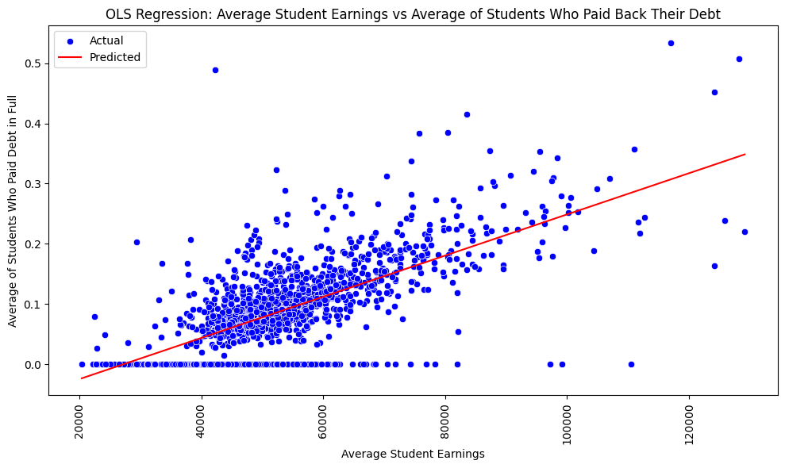

```python
X = df_undergrad[['MD_EARN_WNE_P10']]
y = df_undergrad['BBRR2_FED_UGCOMP_PAIDINFULL_SUPP']

#add a constant term to the features (for the intercept)
X = sm.add_constant(X)

#creates and fit the OLS model
model = sm.OLS(y, X).fit()

#prints the model summary
print(model.summary())

#create a scatter plot with the OLS regression line
plt.figure(figsize=(10, 6))
sns.scatterplot(x=X['MD_EARN_WNE_P10'], y=y, color='blue', label='Actual')
sns.lineplot(x=X['MD_EARN_WNE_P10'], y=model.predict(X), color='red', label='Predicted')
plt.xlabel('Average Student Earnings')
plt.ylabel('Average of Students Who Paid Debt in Full')
plt.title('OLS Regression: Average Student Earnings vs Average of Students Who Paid Back Their Debt')
plt.legend()
plt.xticks(rotation='vertical')
plt.tight_layout()

plt.show()
```

```
                                 OLS Regression Results
=======================================================================================
Dep. Variable:        MD_EARN_WNE_P10   R-squared (uncentered):                   0.968
Model:                            OLS   Adj. R-squared (uncentered):              0.968
Method:                 Least Squares   F-statistic:                              3957.
Date:                Mon, 21 Aug 2023   Prob (F-statistic):                        0.00
Time:                        02:00:06   Log-Likelihood:                         -12721.
No. Observations:                1195   AIC:                                  2.546e+04
Df Residuals:                    1186   BIC:                                  2.551e+04
Df Model:                           9
Covariance Type:            nonrobust
====================================================================================================
                                       coef    std err          t      P>|t|      [0.025      0.975]
----------------------------------------------------------------------------------------------------
ADM_RATE                           546.7511   1423.520      0.384      0.701   -2246.148    3339.650
UGDS                                 0.1147      0.043      2.686      0.007       0.031       0.198
TUITIONFEE_IN                       -0.1299      0.053     -2.464      0.014      -0.233      -0.026
TUITIONFEE_OUT                       0.4428      0.066      6.709      0.000       0.313       0.572
GRAD_DEBT_MDN                        0.5323      0.060      8.904      0.000       0.415       0.650
BOOKSUPPLY                           0.1781      0.609      0.293      0.770      -1.016       1.372
BBRR2_FED_UGCOMP_PAIDINFULL_SUPP  1.101e+05   5044.521     21.830      0.000       1e+05     1.2e+05
total_expenses_off                   1.2352      0.068     18.217      0.000       1.102       1.368
total_expenses_on                    0.0233      0.073      0.319      0.749      -0.120       0.166
==============================================================================
Omnibus:                      225.266   Durbin-Watson:                   2.032
Prob(Omnibus):                  0.000   Jarque-Bera (JB):              990.785
Skew:                           0.822   Prob(JB):                    7.14e-216
Kurtosis:                       7.147   Cond. No.                     9.41e+05
==============================================================================

Notes:
[1] R² is computed without centering (uncentered) since the model does not contain a constant.
[2] Standard Errors assume that the covariance matrix of the errors is correctly specified.
[3] The condition number is large, 9.41e+05. This might indicate that there are
strong multicollinearity or other numerical problems.
```

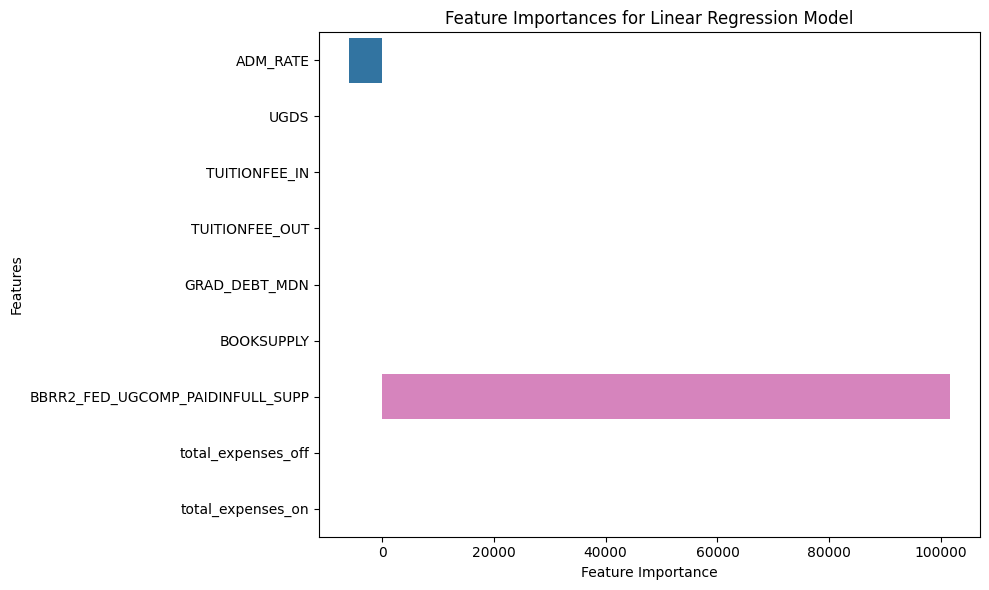

```python
#select the features and target variable
features = ['ADM_RATE', 'UGDS', 'TUITIONFEE_IN', 'TUITIONFEE_OUT', 'GRAD_DEBT_MDN',
            'BOOKSUPPLY', 'BBRR2_FED_UGCOMP_PAIDINFULL_SUPP', 'total_expenses_off','total_expenses_on']

X = df_undergrad[features]
y = df_undergrad['MD_EARN_WNE_P10']



#split the data into training and testing sets
X_train, X_test, y_train, y_test = train_test_split(X, y, test_size=0.2, random_state=42)

#create a linear regression model
model = LinearRegression()

#fit the model to the training data
model.fit(X_train, y_train)

#calculates feature importances using coefficients
feature_importances = model.coef_

model = sm.OLS(y_train, X_train).fit()
print(model.summary())



#plots data
plt.figure(figsize=(10, 6))
sns.barplot(x=feature_importances, y=features)
plt.xlabel('Feature Importance')
plt.ylabel('Features')
plt.title('Feature Importances for Linear Regression Model')
plt.tight_layout()

plt.show()
```

```python
model_orig = smf.ols(formula='MD_EARN_WNE_P10 ~ ADM_RATE + BBRR2_FED_UGCOMP_PAIDINFULL_SUPP', data=df_undergrad).fit()

#new linear regression model that includes the interaction term
model_newe = smf.ols(formula='MD_EARN_WNE_P10 ~ ADM_RATE + BBRR2_FED_UGCOMP_PAIDINFULL_SUPP+ ADM_RATE:regions', data=df_undergrad).fit()

#performs the F-test to compare the two models
f_statistic = model_orig.fvalue
f_p_value = model_newe.f_pvalue

new_stat = model_orig.fvalue
new_stat_p = model_newe.f_pvalue
#prints the F-statistic and p-value
print("F-statistic (Model 2):", f_statistic)
print("p-value (Model 2):", f_p_value)
print("F-statistic (Model 6):", new_stat)
print("p-value (Model 6):", new_stat_p)
```

```
F-statistic (Model 2): 679.2275031437717
p-value (Model 2): 1.6931707119486943e-213
F-statistic (Model 6): 679.2275031437717
p-value (Model 6): 1.6931707119486943e-213
```

Conclusion:

In conclusion, our analysis focused on the critical question of how various factors influence students' future earnings and whether the choice of an expensive education significantly impacts career outcomes. By leveraging hypothesis testing and machine learning techniques, we gained insights that are valuable for students and educators.

My investigation revealed important insights that could have far-reaching implications for prospective students and educational institutions. Specifically, we examined the influence of admission rates and the proportion of students who successfully repaid their debts on future earnings.

As the educational landscape continues to evolve, these insights provide a valuable guidepost for students, educators, and policymakers to shape decisions that lead to prosperous and financially sound futures.